# Infraestrutura

> Versão do Python e ambiente virtual

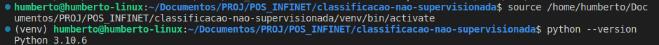

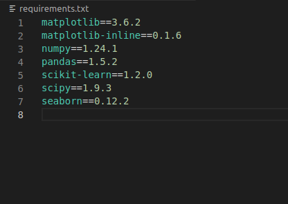

# Libs

```python
import pandas as pd
import matplotlib.pyplot as plt
import seaborn as sns
import numpy as np
from scipy.spatial import distance
from sklearn.cluster import KMeans
from sklearn.decomposition import PCA
from scipy.cluster.hierarchy import dendrogram, linkage
from sklearn.cluster import AgglomerativeClustering
```

# Escolha de base de dados

1. Baixe os dados disponibilizados na plataforma Kaggle sobre dados sócio-econômicos e de saúde que determinam o índice de desenvolvimento de um país. Esses dados estão disponibilizados através do link: https://www.kaggle.com/datasets/rohan0301/unsupervised-learning-on-country-data

```python
df = pd.read_csv('Country-data.csv')
df
```

|  | country | child_mort | exports | health | imports | income | inflation | life_expec | total_fer | gdpp |
| --- | --- | --- | --- | --- | --- | --- | --- | --- | --- | --- |
| 0 | Afghanistan | 90.2 | 10.0 | 7.58 | 44.9 | 1610 | 9.44 | 56.2 | 5.82 | 553 |
| 1 | Albania | 16.6 | 28.0 | 6.55 | 48.6 | 9930 | 4.49 | 76.3 | 1.65 | 4090 |
| 2 | Algeria | 27.3 | 38.4 | 4.17 | 31.4 | 12900 | 16.10 | 76.5 | 2.89 | 4460 |
| 3 | Angola | 119.0 | 62.3 | 2.85 | 42.9 | 5900 | 22.40 | 60.1 | 6.16 | 3530 |
| 4 | Antigua and Barbuda | 10.3 | 45.5 | 6.03 | 58.9 | 19100 | 1.44 | 76.8 | 2.13 | 12200 |
| ... | ... | ... | ... | ... | ... | ... | ... | ... | ... | ... |
| 162 | Vanuatu | 29.2 | 46.6 | 5.25 | 52.7 | 2950 | 2.62 | 63.0 | 3.50 | 2970 |
| 163 | Venezuela | 17.1 | 28.5 | 4.91 | 17.6 | 16500 | 45.90 | 75.4 | 2.47 | 13500 |
| 164 | Vietnam | 23.3 | 72.0 | 6.84 | 80.2 | 4490 | 12.10 | 73.1 | 1.95 | 1310 |
| 165 | Yemen | 56.3 | 30.0 | 5.18 | 34.4 | 4480 | 23.60 | 67.5 | 4.67 | 1310 |
| 166 | Zambia | 83.1 | 37.0 | 5.89 | 30.9 | 3280 | 14.00 | 52.0 | 5.40 | 1460 |

167 rows × 10 columns

2. Quantos paises existem no dataset?

Resposta:

```python
df.country.nunique()
```

```
167
```

3. Mostre através de gráficos a faixa dinâmica das variáveis que serão usadas nas tarefas

de clusterização. Analise os resultados mostrados. O que deve ser feito com os dados antes da etapa de clusterização?

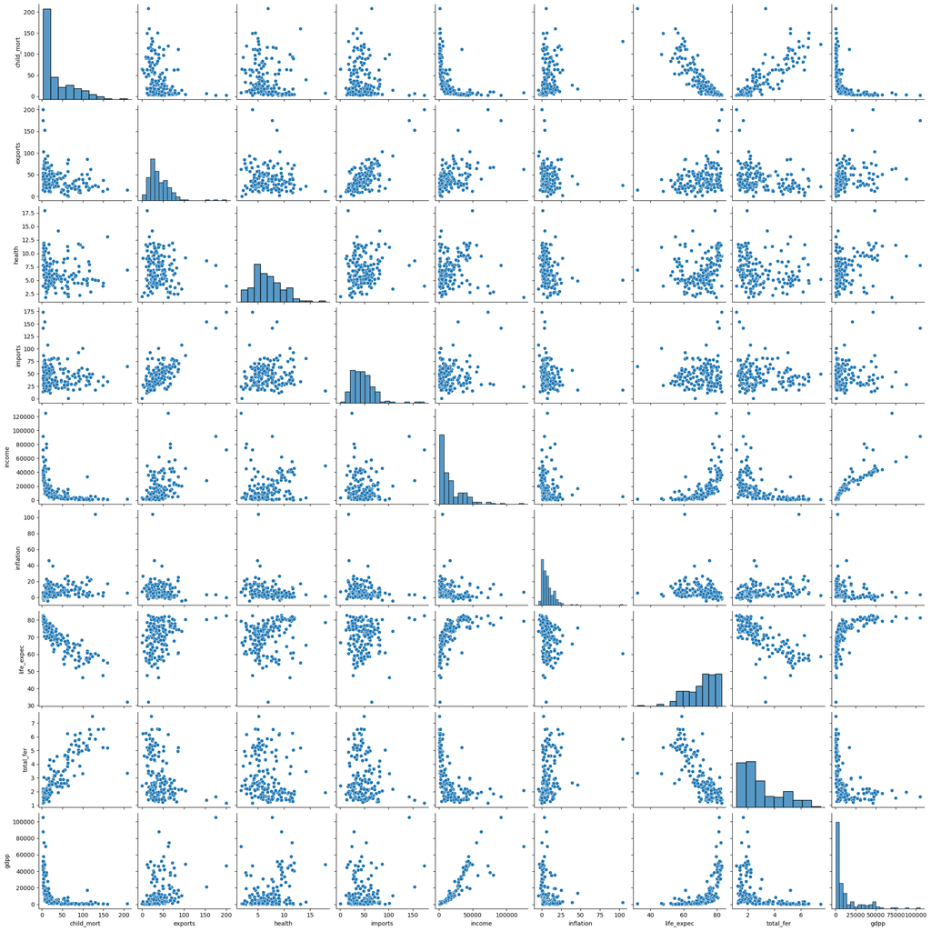

```python
sns.pairplot(df)
```

Resposta: As variáveis devem ser padronizadas, pois estão fora de escala

4. Realize o pré-processamento adequado dos dados.

```python
df_norm = (df-df.mean())/df.std()
df_norm['country'] = df.country
df_norm
```

|  | child_mort | country | exports | gdpp | health | imports | income | inflation | life_expec | total_fer |
| --- | --- | --- | --- | --- | --- | --- | --- | --- | --- | --- |
| 0 | 1.287660 | Afghanistan | -1.134867 | -0.677143 | 0.278251 | -0.082208 | -0.805822 | 0.156864 | -1.614237 | 1.897176 |
| 1 | -0.537333 | Albania | -0.478220 | -0.484167 | -0.096725 | 0.070624 | -0.374243 | -0.311411 | 0.645924 | -0.857394 |
| 2 | -0.272015 | Algeria | -0.098824 | -0.463980 | -0.963176 | -0.639838 | -0.220182 | 0.786908 | 0.668413 | -0.038289 |
| 3 | 2.001787 | Angola | 0.773056 | -0.514720 | -1.443729 | -0.164820 | -0.583289 | 1.382894 | -1.175698 | 2.121770 |
| 4 | -0.693548 | Antigua and Barbuda | 0.160186 | -0.041692 | -0.286034 | 0.496076 | 0.101427 | -0.599944 | 0.702147 | -0.540321 |
| ... | ... | ... | ... | ... | ... | ... | ... | ... | ... | ... |
| 162 | -0.224902 | Vanuatu | 0.200315 | -0.545273 | -0.569997 | 0.239979 | -0.736313 | -0.488315 | -0.849606 | 0.364658 |
| 163 | -0.524935 | Venezuela | -0.459980 | 0.029235 | -0.693776 | -1.209860 | -0.033442 | 3.606020 | 0.544723 | -0.315728 |
| 164 | -0.371199 | Vietnam | 1.126916 | -0.635842 | 0.008851 | 1.375892 | -0.656429 | 0.408503 | 0.286097 | -0.659224 |
| 165 | 0.447072 | Yemen | -0.405259 | -0.635842 | -0.595481 | -0.515920 | -0.656948 | 1.496416 | -0.343599 | 1.137523 |
| 166 | 1.111607 | Zambia | -0.149897 | -0.627658 | -0.337002 | -0.660491 | -0.719195 | 0.588245 | -2.086510 | 1.619738 |

167 rows × 10 columns

# Clusterização

1. Realizar o agrupamento dos países em 3 grupos distintos. Para tal, use:

```
    a. K-Médias
```

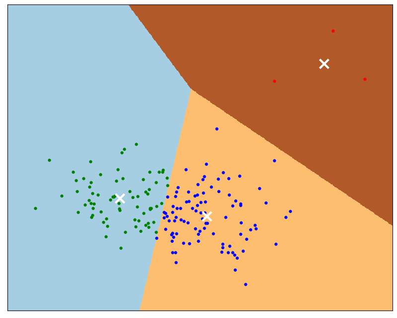

```python
reduced_data = PCA(n_components=2).fit_transform(df_norm.drop(columns=
['country']))
kmeans = KMeans(n_clusters=3, random_state=0)
fit = kmeans.fit(reduced_data)
# Step size of the mesh. Decrease to increase the quality of the VQ.
h = 0.02
# point in the mesh [x_min, x_max]x[y_min, y_max].
# Plot the decision boundary. For that, we will assign a color to each
x_min, x_max = reduced_data[:, 0].min() - 1, reduced_data[:, 0].max() + 1
y_min, y_max = reduced_data[:, 1].min() - 1, reduced_data[:, 1].max() + 1
xx, yy = np.meshgrid(np.arange(x_min, x_max, h), np.arange(y_min, y_max, h))
# Obtain labels for each point in mesh. Use last trained model.
Z = kmeans.predict(np.c_[xx.ravel(), yy.ravel()])
# Put the result into a color plot
Z = Z.reshape(xx.shape)
plt.figure(1, figsize=[10, 8])
plt.clf()
plt.imshow(
    Z,
    interpolation="nearest",
    extent=(xx.min(), xx.max(), yy.min(), yy.max()),
    cmap=plt.cm.Paired,
    aspect="auto",
    origin="lower",
)
labels = pd.Series(kmeans.labels_)
for label in [0, 1, 2]:
    dict_color = {0: 'green', 1: 'blue', 2: 'red'}
    plt.plot(reduced_data[labels[labels == label].index, 0],
reduced_data[labels[labels == label].index, 1], "k.", markersize=7,
color=dict_color[label])
# Plot the centroids as a white X
centroids = kmeans.cluster_centers_
plt.scatter(
centroids[:, 0],
centroids[:, 1],
marker="x",
s=169,
linewidths=3,
color="w",
zorder=10,
)
plt.xlim(x_min, x_max)
plt.ylim(y_min, y_max)
plt.xticks(())
plt.yticks(())
plt.show()
```

```
    b. Clusterização Hierárquica
```

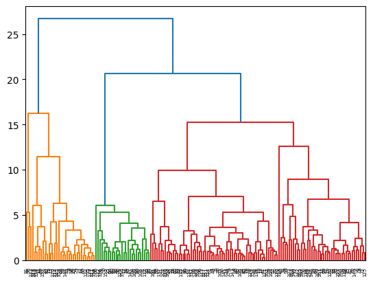

```python
base = df_norm.drop(columns=['country'])
dendrograma = dendrogram(linkage(base, method = 'ward'))
hc = AgglomerativeClustering(n_clusters = 3, affinity = 'euclidean', linkage =
'ward')
previsoes = hc.fit_predict(base)
```

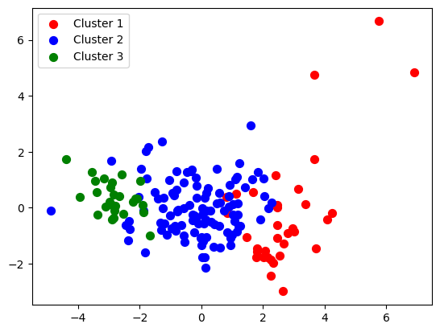

```python
plt.scatter(reduced_data[previsoes == 0, 0], reduced_data[previsoes == 0, 1], s =
50, c = 'red', label = 'Cluster 1')
plt.scatter(reduced_data[previsoes == 1, 0], reduced_data[previsoes == 1, 1], s =
50, c = 'blue', label = 'Cluster 2')
plt.scatter(reduced_data[previsoes == 2, 0], reduced_data[previsoes == 2, 1], s =
50, c = 'green', label = 'Cluster 3')
plt.legend()
```

```python
df_norm['distance_to_center'] = np.min(fit.transform(reduced_data), axis=1)
df_norm['label_kmeans'] = fit.labels_
df_norm['label_hclust'] = previsoes
```

2. Para os resultados, do K-Médias:

```
    a. Interprete cada um dos clusters obtidos citando:
```

```
        i. Qual a distribuição das dimensões em cada grupo
```

> Resposta: Dataset abaixo

```python
df['label_kmeans'] = df_norm['label_kmeans']
columns = ['child_mort', 'exports', 'gdpp', 'health', 'imports', 'income', 'inflation', 'life_expec', 'total_fer']
df.groupby('label_kmeans')[columns].mean()
```

| label_kmeans | child_mort | exports | gdpp | health | imports | income | inflation | life_expec | total_fer |
| --- | --- | --- | --- | --- | --- | --- | --- | --- | --- |
| 0 | 74.156338 | 30.611254 | 2019.211268 | 6.015915 | 44.071351 | 4363.281690 | 11.094859 | 62.277465 | 4.329437 |
| 1 | 11.974194 | 44.772043 | 19881.182796 | 7.426989 | 45.501075 | 25390.000000 | 5.423946 | 76.524731 | 1.943871 |
| 2 | 4.133333 | 176.000000 | 57566.666667 | 6.793333 | 156.666667 | 64033.333333 | 2.468000 | 81.433333 | 1.380000 |

```
        ii. O país, de acordo com o algoritmo, melhor representa o seu agrupamento. Justifique
```

> Resposta:
- Grupo 0: Senegal
- Grupo 1: Lebanon
- Grupo 2: Singapore

São os países que tem a menor distância ao seu respctivo centroide, e possuem a distribuição das variáveis próximas a média dos seus respectivos grupos.

```python
df_norm.sort_values('distance_to_center').groupby('label_kmeans').agg(
    country=('country', 'first'),
    distance_to_center=('distance_to_center', 'min')
)
```

[output not shown]

```python
df.query('country in ["Senegal", "Lebanon", "Singapore"]')
```

[output not shown]

3. Para os resultados da Clusterização Hierárquica, apresente o dendograma e interprete

os resultados

> Resposta:
- De acordo com a distribuição das variáveis, o algoritimo Clusterização Hierárquica formou os grupos separando as cidades em níveis socioeconômicos, onde no grupo 2 fazem parte os países com piores índices de desenvolvimento. No grupo 1 foram agrupados os países com as melhores medidas, em comparação ao grupo 2 e no grupo 0 foram reunidas os melhores países com os melhores indicadores entre os três grupos.

```python
df['label_hclust'] = df_norm['label_hclust']
columns = ['child_mort', 'exports', 'gdpp', 'health', 'imports', 'income', 'inflation', 'life_expec', 'total_fer']
df.groupby('label_hclust')[columns].mean()
```

| label_hclust | child_mort | exports | gdpp | health | imports | income | inflation | life_expec | total_fer |
| --- | --- | --- | --- | --- | --- | --- | --- | --- | --- |
| 0 | 5.961765 | 58.508824 | 43170.588235 | 8.501176 | 48.902941 | 47588.235294 | 4.115500 | 79.982353 | 1.888529 |
| 1 | 31.617925 | 39.990368 | 6407.367925 | 6.353679 | 48.085527 | 11341.886792 | 9.120604 | 70.921698 | 2.654623 |
| 2 | 105.070370 | 23.589630 | 667.888889 | 6.507037 | 39.662963 | 1589.740741 | 7.142778 | 57.248148 | 5.433704 |

```python
df.groupby('label_kmeans')[columns].mean()
```

| label_kmeans | child_mort | exports | gdpp | health | imports | income | inflation | life_expec | total_fer |
| --- | --- | --- | --- | --- | --- | --- | --- | --- | --- |
| 0 | 74.156338 | 30.611254 | 2019.211268 | 6.015915 | 44.071351 | 4363.281690 | 11.094859 | 62.277465 | 4.329437 |
| 1 | 11.974194 | 44.772043 | 19881.182796 | 7.426989 | 45.501075 | 25390.000000 | 5.423946 | 76.524731 | 1.943871 |
| 2 | 4.133333 | 176.000000 | 57566.666667 | 6.793333 | 156.666667 | 64033.333333 | 2.468000 | 81.433333 | 1.380000 |

4. Compare os dois resultados, aponte as semelhanças e diferenças e interprete

```python
df.value_counts('label_hclust')
```

```
label_hclust
1    106
0     34
2     27
dtype: int64
```

```python
df.value_counts('label_kmeans')
```

```
label_kmeans
1    93
0    71
2     3
dtype: int64
```

# Escolha de algoritmos

1. Escreva em tópicos as etapas do algoritmo de K-médias até sua convergência.

> Resposta

```
    A. São escolhidos pontos aletorios para representar os centroides
    B. A distâncias entre os centroides e os pontos são calculadas e armazenadas
    C. Com base nos cálculos de distância, cada ponto é atribuído ao cluster mais próximo
    D. As novas posições do centróide do cluster são atualizadas para o ponto de melhor representatividade do cluster
    E. Se os locais dos centróides mudaram, o processo se repete a partir da etapa 2, até que o novo centro calculado permaneça o mesmo ou muito próximo, o que sinaliza que os membros e os centróides dos clusters agora estão definidos.
```

2. Refaça o algoritmo apresentado na questão 1 a fim de garantir que o cluster seja representado pelo dado mais próximo ao seu baricentro em todas as iterações do algoritmo.

```python
df.query('country in ["Senegal", "Lebanon", "Singapore"]')
```

|  | country | child_mort | exports | health | imports | income | inflation | life_expec | total_fer | gdpp | label | label_kmeans | label_hclust |
| --- | --- | --- | --- | --- | --- | --- | --- | --- | --- | --- | --- | --- | --- |
| 86 | Lebanon | 10.3 | 35.8 | 7.03 | 60.2 | 16300 | 0.238 | 79.8 | 1.61 | 8860 | 1 | 1 | 1 |
| 129 | Senegal | 66.8 | 24.9 | 5.66 | 40.3 | 2180 | 1.850 | 64.0 | 5.06 | 1000 | 0 | 0 | 2 |
| 133 | Singapore | 2.8 | 200.0 | 3.96 | 174.0 | 72100 | -0.046 | 82.7 | 1.15 | 46600 | 2 | 2 | 0 |

```python
list_medoides = reduced_data[[129, 86, 133]]
labels_medoides = []
for point in reduced_data:
    list_distance = []
    for medoid in list_medoides:
        list_distance.append(distance.euclidean(point, medoid))
    min_distance = min(list_distance)
    labels_medoides.append(list_distance.index(min_distance))
pd.Series(labels_medoides).value_counts()
```

```
1    94
0    70
2     3
dtype: int64
```

```python
df_norm.value_counts('label_kmeans')
```

```
label_kmeans
1    93
0    71
2     3
dtype: int64
```

3. O algoritmo de K-médias é sensível a outliers nos dados. Explique.

> Resposta:
- sim, pois usa a média dos pontos para encontrar o centro do cluster,

fazendo com que ele seja suscetível a erros provocados por outliers

4. Por que o algoritmo de DBScan é mais robusto à presença de outliers?

> Resposta:
- O algoritmo do Dbscan agrupa pontos que estão próximos, marcando como outliers pontos que estão sozinhos em regiões de baixa densidade. Fazendo com que ele identifique melhor os outliers.